# Data Analyst @ Gousto

Konstantinos Anthis

01 December 2018

# 1 Approach and Actions

## 1.1 Approach

The data set of this exercise contains information about **852,761 orders** made by **156,189 customers** from *January 2014 to January 2016*. There are only six features for each order in the initial data set: Order ID, User ID , Period ID, Payment Date, Due Ammount and Paid Ammmount.

I included findings that are important and support my proposals.

**I am assuming that the orders are about gousto’s product.**

My approach is to analyse this dataset looking at two sides:

**1. By customer**

- Create a data set aggregating data by customer and engineering new features
- New features: Tenure, Frequency of purchase, Monetary value, recency of purchase, Churn and Retention, cost of the customer and net value of the customer.

**2. By order**

- Create some descriptive measures to find out information for orders per year, month, week day or period

## 1.2 Actions

Proposed actions:

1. **Create a relationship with new customers to retain new customers for more than a month:**
   - Analyze what channels of communication with customer are available and how the customer responds to each channel
   - Make special offers for new customers (what about cooking tools or wine to company the meal?). (As I was writing this I saw your “Get 35% off all boxes in your first month” offer in gousto website)
   - Use the customer base to create a community where the customers can help each other, welcome new customers, share experiences and cooking ‘secrets’, opinions and recomendations about recipes etc
   - ‘Personal chef’ option for new customers: A chef/cook goes to the customer’s location in order to cook with the customer (like a live course). This service can be given for free during the first week or charging a small ammount
2. **Special offers and activities during the weekend:**
   - Saturday and Sunday have the fewest orders with the highest avegare ammount paid and costs at the same level as the rest of the days
   - Weekend community cooking competitions: Each customer can cook and share the dish online in order to get votes about the appearence of the dish, the creativity etc. Highest voted customers get a gift from gousto.
   - Even on site competitions: Create a space for cooking courses and competitions for the weekend

*Note: Some of these actions may be already in place*

# 2 Orders Analysis

## 2.1 Week Days orders

- **During the Weekend (Saturday and Sunday) customers seem to spend more on average than during other days:**

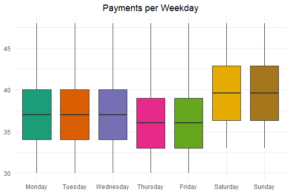

Weekend seems to have higher payments compared to other weekdays. Increasing the ammount of orders during the weekend is the way to go

```r
gousto  %>% mutate(payment_made = factor(weekdays(payment_made),
                                         c('Monday',
                                           'Tuesday',
                                           'Wednesday',
                                           'Thursday',
                                           'Friday',
                                           'Saturday',
                                           'Sunday'))) %>%
  ggplot(aes(x = payment_made,
             y = total_paid,
             fill = payment_made)) +
  geom_boxplot() +
  theme_minimal() +
  scale_fill_brewer(palette = 'Dark2',
                    name = 'Weekday') +
  ggtitle('Payments per Weekday') +
  theme(axis.title.x = element_blank(),
        axis.title.y = element_blank(),
        plot.title = element_text(hjust = 0.5),
        legend.position = 'none')
```

- At the same time, during the weekend the ammount of orders reduces significantly:

```r
gousto  %>% group_by(Weekday = weekdays(payment_made)) %>%
  summarise(Orders = format(n(),
                            big.mark = ',',
                            decimal.mark = '.'),
            'Avg Paid' = paste(format(mean(total_paid),
                                      big.mark = ',',
                                      decimal.mark = '.',
                                      digits = 3),
                               '£'),
            'Avg Due' = paste(format(mean(total_due),
                                     big.mark = ',',
                                     decimal.mark = '.',
                                     digits = 3),
                              "£"),
            'TTL Paid' = paste(format(sum(total_paid),
                                     big.mark = ',',
                                     decimal.mark = '.'),
                              "£"),
            'TTL Due' = paste(format(sum(total_due),
                                     big.mark = ',',
                                     decimal.mark = '.'),
                              "£"))
```

| Weekday | Orders | Avg Paid | Avg Due | TTL Paid | TTL Due |
| --- | --- | --- | --- | --- | --- |
| Friday | 108,683 | 36.4 £ | 35 £ | 3,956,705 £ | 3,806,220 £ |
| Monday | 170,246 | 37.1 £ | 35 £ | 6,321,033 £ | 5,953,422 £ |
| Saturday | 82,718 | 39.6 £ | 35.1 £ | 3,273,461 £ | 2,903,679 £ |
| Sunday | 82,487 | 39.4 £ | 35 £ | 3,253,644 £ | 2,888,778 £ |
| Thursday | 109,933 | 36.4 £ | 35 £ | 4,005,769 £ | 3,847,560 £ |
| Tuesday | 167,328 | 37.1 £ | 34.9 £ | 6,210,201 £ | 5,848,033 £ |
| Wednesday | 131,366 | 37.3 £ | 35 £ | 4,906,387 £ | 4,604,180 £ |

## 2.2 Orders by month

The number of Orders increase during December

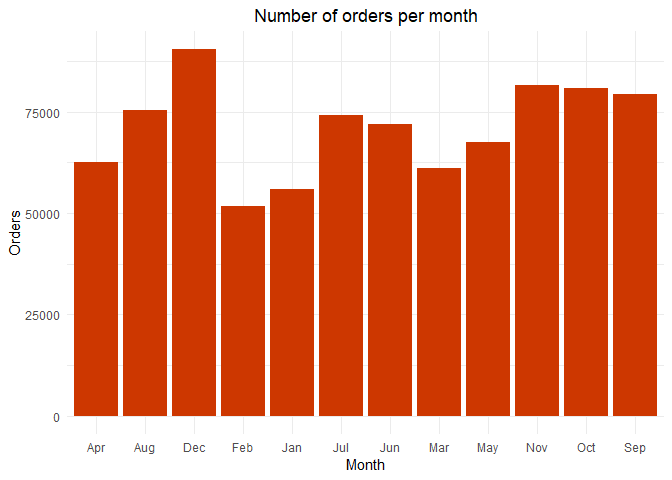

```r
gousto  %>%
  group_by(Month = month.abb[month(payment_made)]) %>%
  summarise(Orders = n(),
            Avg_Paid = mean(total_paid),

            Avg_Due = mean(total_due),
            Paid = sum(total_paid),
            Due = sum(total_due))  %>%
  ggplot(aes(x = Month,
             y = Orders)) +
  geom_bar(fill = "#CD3700",
           stat = "identity") +
  theme_minimal() +
  ggtitle('Number of orders per month')+
  theme(plot.title = element_text(hjust = 0.5))
```

# 3 Customers Analysis

The orders data set is aggregated by customers in orders to analyze customer behaviours, detect problems and propose actions:

**The most important problem discovered by analysing customer retention and churn.**

```r
today = dmy('01-01-2017')

Customer <- gousto %>%
  group_by(user_id) %>%
  summarise(Frequency = n(),
            Last_pay = max(payment_made),
            First_pay = min(payment_made),
            Recency = difftime(today ,
                               max(payment_made) ,
                               units = c("days")),
            Paid = sum(total_paid),
            Due = sum(total_due),
            Max_Paid = max(total_paid),
            Max_Due = max(total_due),
            Avg_Paid = mean(total_paid),
            Avg_due = mean(total_due),
            Purchased_Again = ifelse((year(First_pay) < year(Last_pay)),
                                     'YES',
                                     "NO"),
            Tenure = difftime(Last_pay,
                              First_pay,
                              c("days")),
            Diff = Paid - Due,
            Same_month_churn = case_when(Tenure == 0 ~ '0',
                                         Tenure <= 30 ~ '1',
                                         Tenure > 30 ~ '2')
            )
```

## 3.1 **The Problem: Churn, Retention**

- **Major Problem:** **~50%** of the customers churn **at the first day of their order** and **~80%** of the customers churned **the same month they purchased for the first time**:

```r
Customer %>%
  group_by(Retention = factor(Same_month_churn,
                              labels = c('Same day churn',
                                         'Same month churn',
                                         'Retained more than 1 month'))) %>%
  summarise(Count = n(),
            'Average net Value' = format(mean(Diff),
                                         decimal.mark = '.',
                                         digits = 3)) %>%
  mutate('Base Percentage' = paste(format((Count/sum(Count))*100,
                                          decimal.mark = '.',
                                          digits = 4),
                                   '%'),
         Count = format(Count,
                        big.mark = ',')) %>%
  kable('html', align = 'rccc') %>%
  kable_styling(bootstrap_options = "striped")
```

| Retention | Count | Average net Value | Base Percentage |
| --- | --- | --- | --- |
| Same day churn | 80,515 | 2.92 | 51.55 % |
| Same month churn | 47,420 | 5.6 | 30.36 % |
| Retained more than 1 month | 28,254 | 55.7 | 18.09 % |

## 3.2 New Customers (Acquisition) per year

**How many customers are acquired each year ??**

```r
Customer %>%
  group_by('New Customers' = year(First_pay)) %>%
  summarise( Count = format(n(),
                            big.mark = ',') ) %>%
  kable('html', align = 'cc') %>%
  kable_styling(bootstrap_options = "striped")
```

| New Customers | Count |
| --- | --- |
| 2014 | 75,906 |
| 2015 | 79,207 |
| 2016 | 1,076 |

## 3.3 Yearly Retention

```r
Customer %>%
  group_by('First Purchase' = year(First_pay),
           'Last Purchase'= year(Last_pay)) %>%
  summarise( Customers = format(n(),
                                big.mark = ',')) %>%
  kable('html', align = 'ccc') %>%
  kable_styling(bootstrap_options = "striped")
```

| First Purchase | Last Purchase | Customers |
| --- | --- | --- |
| 2014 | 2014 | 67,955 |
| 2014 | 2015 | 5,848 |
| 2014 | 2016 | 2,103 |
| 2015 | 2015 | 74,732 |
| 2015 | 2016 | 4,475 |
| 2016 | 2016 | 1,076 |

## 3.4 Sample Customer Data

Just a sample o the customer data:

```r
datatable(head(Customer,200))
```

|  | user_id | Frequency | Last_pay | First_pay | Recency | Paid | Due | Max_Paid | Max_Due | Avg_Paid | Avg_due | Purchased_Again | Tenure | Diff | Same_month_churn |
| --- | --- | --- | --- | --- | --- | --- | --- | --- | --- | --- | --- | --- | --- | --- | --- |
| 1 | 1 | 2 | 2014-03-26 | 2014-03-19 | 1012 | 60 | 60 | 30 | 30 | 30 | 30 | NO | 7 | 0 | 1 |
| 2 | 2 | 1 | 2015-06-01 | 2015-06-01 | 580 | 35 | 35 | 35 | 35 | 35 | 35 | NO | 0 | 0 | 0 |
| 3 | 3 | 9 | 2015-09-18 | 2015-07-24 | 471 | 342 | 342 | 38 | 38 | 38 | 38 | NO | 56 | 0 | 2 |
| 4 | 4 | 1 | 2015-10-05 | 2015-10-05 | 454 | 39 | 39 | 39 | 39 | 39 | 39 | NO | 0 | 0 | 0 |
| 5 | 5 | 3 | 2015-12-28 | 2015-12-14 | 370 | 102 | 102 | 34 | 34 | 34 | 34 | NO | 14 | 0 | 1 |
| 6 | 6 | 1 | 2015-02-19 | 2015-02-19 | 682 | 31 | 31 | 31 | 31 | 31 | 31 | NO | 0 | 0 | 0 |
| 7 | 7 | 3 | 2015-08-25 | 2015-08-11 | 495 | 108 | 108 | 36 | 36 | 36 | 36 | NO | 14 | 0 | 1 |
| 8 | 8 | 81 | 2015-12-29 | 2014-06-17 | 369 | 3159 | 3159 | 39 | 39 | 39 | 39 | YES | 560 | 0 | 2 |
| 9 | 9 | 1 | 2014-08-08 | 2014-08-08 | 877 | 32 | 32 | 32 | 32 | 32 | 32 | NO | 0 | 0 | 0 |
| 10 | 10 | 1 | 2014-05-21 | 2014-05-21 | 956 | 39 | 39 | 39 | 39 | 39 | 39 | NO | 0 | 0 | 0 |

[output cut: 190 more lines]

# 4 Next Steps

There is much more information that can be mined from this dataset in order to get a better understanding about the customer behaviour. As next step, I would break the customer base into segments in order to look at them under every possible perspective. This could reveal customer segment with a special behaviour that would lead us to relevant actions.